# AED - Datacamp - Chap03

WHSP

9 de outubro de 2017

## Measures of center

#### Calculate center measures

Throughout this chapter, you will use data from gapminder, which tracks demographic data in countries of the world over time. To learn more about it, you can bring up the help file with ?gapminder.

For this exercise, focus on how the life expectancy differs from continent to continent. This requires that you conduct your analysis not at the country level, but aggregated up to the continent level. This is made possible by the one-two punch of group_by() and summarize(), a very powerful syntax for carrying out the same analysis on different subsets of the full dataset.

**Instructions**

1- Create a dataset called gap2007 that contains only data from the year 2007.

2- Using gap2007, calculate the mean and median life expectancy for each continent. Don’t worry about naming the new columns produced by summarize().

3- Confirm the trends that you see in the medians by generating side-by-side box plots of life expectancy for each continent.

```r
gapminder <- gapminder::gapminder
```

```r
# Create dataset of 2007 data
gap2007 <- filter(gapminder, year == 2007)

# Compute groupwise mean and median lifeExp, no name for new variables
gap2007 %>%
  group_by(continent) %>%
  summarize(mean(lifeExp),
            median(lifeExp))
```

```
## # A tibble: 5 x 3
##   continent `mean(lifeExp)` `median(lifeExp)`
##      <fctr>           <dbl>             <dbl>
## 1    Africa        54.80604           52.9265
## 2  Americas        73.60812           72.8990
## 3      Asia        70.72848           72.3960
## 4    Europe        77.64860           78.6085
## 5   Oceania        80.71950           80.7195
```

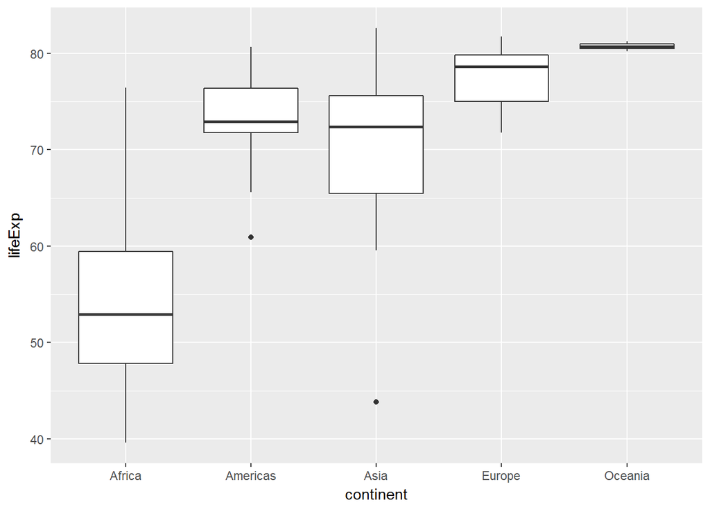

```r
# Generate box plots of lifeExp for each continent
gap2007 %>%
  ggplot(aes(x = continent, y = lifeExp)) +
  geom_boxplot()
```

#### Calculate spread measures

Let’s extend the powerful group_by() and summarize() syntax to measures of spread. If you’re unsure whether *you’re working with symmetric or skewed distributions, it’s a **good idea to consider a robust measure like IQR** in addition to the usual measures of variance or standard deviation*.

**Instructions**

1- For each continent in gap2007, summarize life expectancies using the sd(), the IQR(), and the count of countries, n(). No need to name the new columns produced here. The n() function within your summarize() call does not take any arguments.

2- Graphically compare the spread of these distributions by constructing overlaid density plots of life expectancy broken down by continent.

```r
# Compute groupwise measures of spread
gap2007 %>%
  group_by(continent) %>%
  summarize(sd(lifeExp),
            IQR(lifeExp),
            n())
```

```
## # A tibble: 5 x 4
##   continent `sd(lifeExp)` `IQR(lifeExp)` `n()`
##      <fctr>         <dbl>          <dbl> <int>
## 1    Africa     9.6307807       11.61025    52
## 2  Americas     4.4409476        4.63200    25
## 3      Asia     7.9637245       10.15200    33
## 4    Europe     2.9798127        4.78250    30
## 5   Oceania     0.7290271        0.51550     2
```

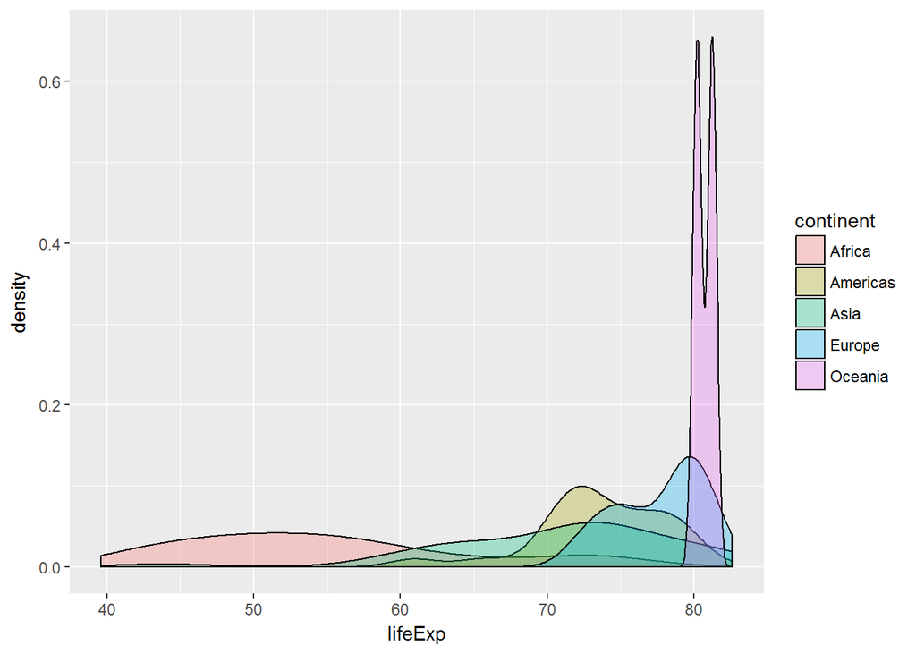

```r
# Generate overlaid density plots
gap2007 %>%
  ggplot(aes(x = lifeExp, fill = continent)) +
  geom_density(alpha = 0.3)
```

#### Choose measures for center and spread

Consider the density plots shown here. What are the most appropriate measures to describe their centers and spreads? In this exercise, you’ll select the measures and then calculate them.

**Instructions**

Using the shapes of the density plots, calculate the most appropriate measures of center and spread for the following:

1- The distribution of life expectancy in the countries of the Americas. Note you’ll need to apply a filter here.

2- The distribution of country populations across the entire gap2007 dataset.

```r
# Compute stats for lifeExp in Americas
gap2007 %>%
  filter(continent == "Americas") %>%
  summarize(sd(lifeExp),
            mean(lifeExp))
```

```
## # A tibble: 1 x 2
##   `sd(lifeExp)` `mean(lifeExp)`
##           <dbl>           <dbl>
## 1      4.440948        73.60812
```

```r
# Compute stats for population
gap2007 %>%
  summarize(median(pop),
            IQR(pop))
```

```
## # A tibble: 1 x 2
##   `median(pop)` `IQR(pop)`
##           <dbl>      <dbl>
## 1      10517531   26702008
```

Like **mean and standard deviation**, **median and IQR** measure the central tendency and spread, respectively, *but are robust to outliers and non-normal data*.

#### Transformations

Highly skewed distributions can make it very difficult to learn anything from a visualization. Transformations can be helpful in revealing the more subtle structure.

Here you’ll focus on the population variable, which exhibits strong right skew, and transform it with the natural logarithm function (log() in R).

**Instructions**

Using the gap2007 data:

1- Create a density plot of the population variable.

2- Mutate a new column called log_pop that is the natural log of the population and save it back into gap2007.

3- Create a density plot of your transformed variable.

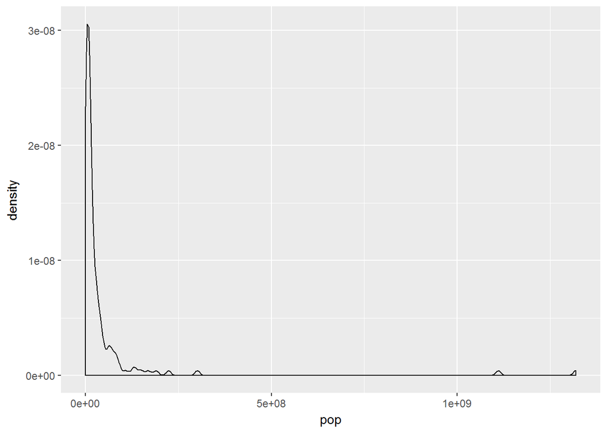

```r
# Create density plot of old variable
gap2007 %>%
  ggplot(aes(x = pop)) +
  geom_density()
```

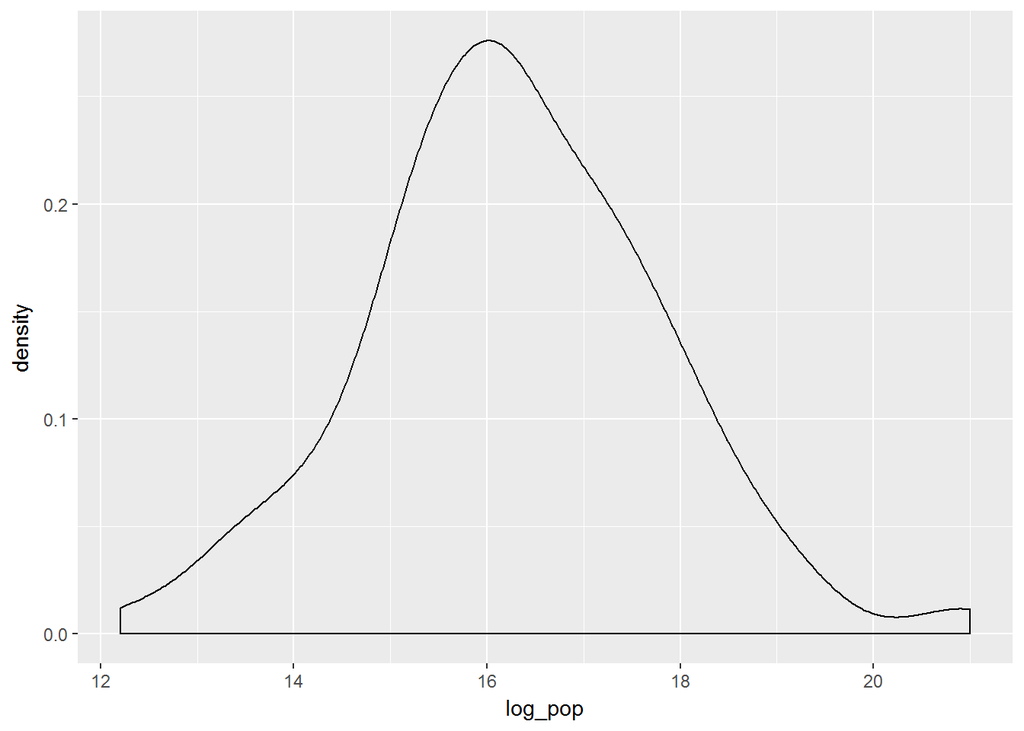

```r
# Transform the skewed pop variable
gap2007 <- gap2007 %>%
  mutate(log_pop = log(pop))

# Create density plot of new variable
gap2007 %>%
  ggplot(aes(x = log_pop)) +
  geom_density()
```

#### Identify outliers

Consider the distribution, shown here, of the life expectancies of the countries in Asia. The box plot identifies one clear outlier: a country with a notably low life expectancy. Do you have a guess as to which country this might be? Test your guess in the console using either min() or filter(), then proceed to building a plot with that country removed.

**Instructions**

gap2007 is still available in your workspace.

1- Apply a filter so that it only contains observations from Asia, then create a new variable called is_outlier that is TRUE for countries with life expectancy less than 50. Assign the result to gap_asia.

2- Filter gap_asia to remove all outliers, then create another box plot of the remaining life expectancies.

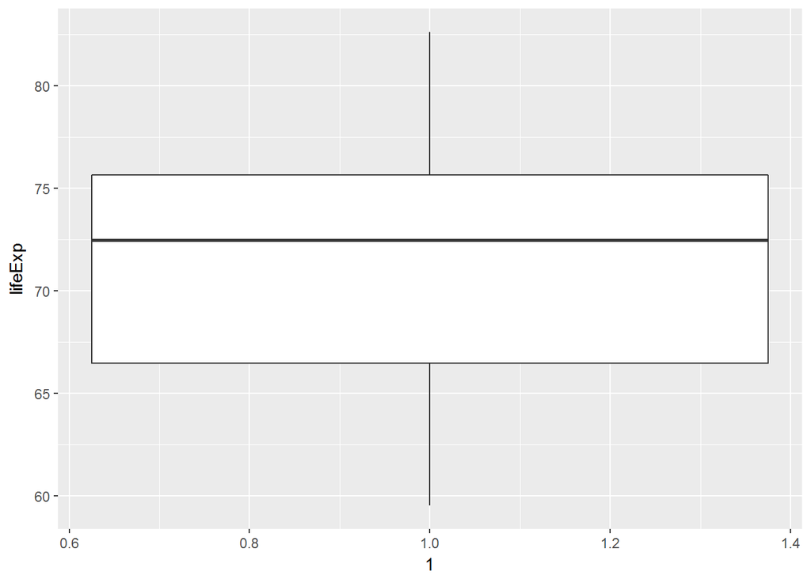

```r
# Filter for Asia, add column indicating outliers
gap_asia <- gap2007 %>%
  filter(continent == "Asia") %>%
  mutate(is_outlier = lifeExp < 50)

# Remove outliers, create box plot of lifeExp
gap_asia %>%
  filter(!is_outlier) %>%
  ggplot(aes(x = 1, y = lifeExp)) +
  geom_boxplot()
```

END OF NUMERICAL SUMMARIES